# R Notebook

# PHS Scottish Stroke Statistics

This notebook contains steps to perform a cluster analysis to cluster/group NHS health boards based on stroke incidence and mortality rates using hierarchical clustering.

This is helpful as it will group health boards based on closest similarity. The outcome can be used by the health boards to seek collaboration opportunities across boards and tackle similar problems together.

```r
library(tidyverse)
library(cluster)
library(corrplot)
library(dendextend)
library(factoextra)
```

Since Cluster analysis (either hierarchical clustering or k-means clustering) do not allow repeteated row-names or identities. This analysis is not suitable for the complete dataset as currently presented, as data is aggregated and occuring many times.

As alternative (time constrained) we are simplifying our methods, and create a single dendrogram based on incidence rate of all ages and sexes taken together, for the most recent year. For an extensive clustering analysis you would include all data.

Load the data

|  | number_of_discharges | crude_rate | easr |
| --- | --- | --- | --- |
| Ayrshire and Arran | 0.065723015 | 0.6230728 | 0.34283875 |
| Borders | -0.649072630 | 0.7071842 | 0.23804769 |
| Dumfries and Galloway | -0.666891898 | -0.3835365 | -0.82775482 |
| Forth Valley | -0.001099241 | 1.1525789 | 1.27983529 |
| Grampian | -0.193466340 | -1.5286027 | -1.17836020 |
| Highland | -0.017703559 | 0.8147439 | 0.38471590 |
| Lothian | 0.520924321 | -1.1096469 | -0.48901142 |
| Orkney | -0.949165305 | -1.0480381 | -1.21384562 |
| Shetland | -0.959289890 | -1.7222032 | -1.52670905 |
| Western Isles | -0.911906836 | 0.5824710 | 0.01472122 |

[output cut: 4 more lines]

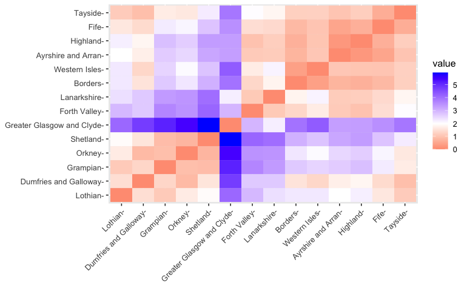

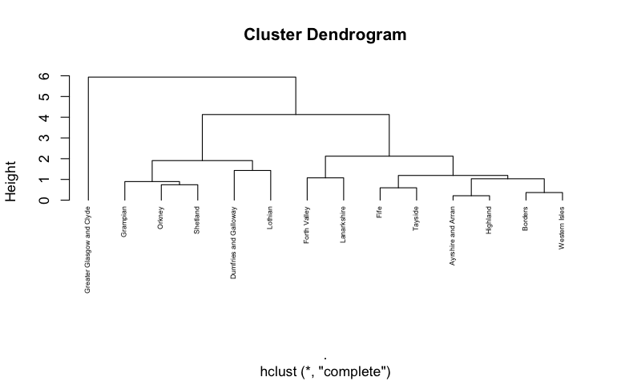

Now do exactly the same but with mortality rates, and compare with dendogram above

| ...1 | id | year | hbr | hbrqf | age_group | age_group_qf | sex | sex_qf | diagnosis | number_of_deaths | number_of_deaths_qf | crude_rate | crude_rate_qf | easr |
| --- | --- | --- | --- | --- | --- | --- | --- | --- | --- | --- | --- | --- | --- | --- |
| 1 | 1 | 2012 | S08000015 | NA | 0-44 years | NA | Males | NA | Cerebrovascular Disease | 1 | NA | 1.063615 | NA | 1.029052 |
| 2 | 2 | 2012 | S08000015 | NA | 0-44 years | NA | Females | NA | Cerebrovascular Disease | 0 | NA | 0.000000 | NA | 0.000000 |
| 3 | 3 | 2012 | S08000015 | NA | 45-64 years | NA | Males | NA | Cerebrovascular Disease | 12 | NA | 23.117378 | NA | 23.048501 |
| 4 | 4 | 2012 | S08000015 | NA | 45-64 years | NA | Females | NA | Cerebrovascular Disease | 10 | NA | 17.811977 | NA | 17.581857 |
| 5 | 5 | 2012 | S08000015 | NA | 65-74 years | NA | Males | NA | Cerebrovascular Disease | 27 | NA | 136.798906 | NA | 145.881251 |
| 6 | 6 | 2012 | S08000015 | NA | 65-74 years | NA | Females | NA | Cerebrovascular Disease | 23 | NA | 104.512201 | NA | 108.042243 |

|  | number_of_deaths | crude_rate | easr |
| --- | --- | --- | --- |
| Ayrshire and Arran | 0.31571819 | 0.9480173 | 1.2514705 |
| Borders | -0.84965337 | 0.1025197 | -0.6050576 |
| Dumfries and Galloway | -0.69643719 | 0.3919545 | -0.8373171 |
| Forth Valley | -0.34357568 | -0.6654975 | -0.3975430 |
| Grampian | 0.56643558 | -0.5418991 | 0.2667027 |
| Highland | -0.05107206 | 0.2599795 | -0.2198940 |
| Lothian | 1.13287116 | -1.1901904 | -0.3326451 |
| Orkney | -1.17001448 | 1.2338652 | 1.0131178 |
| Shetland | -1.22108654 | -1.6965593 | -2.6270647 |
| Western Isles | -1.13287116 | 2.1196278 | 1.1335524 |

[output cut: 4 more lines]

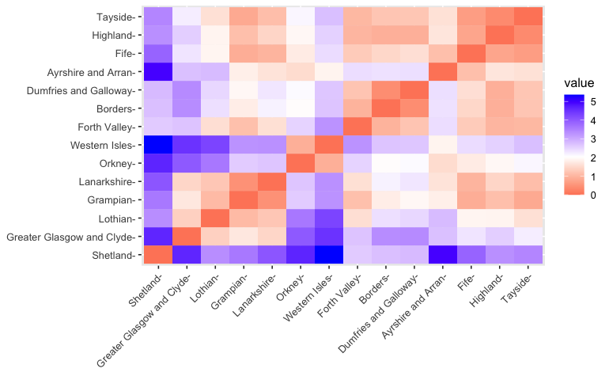

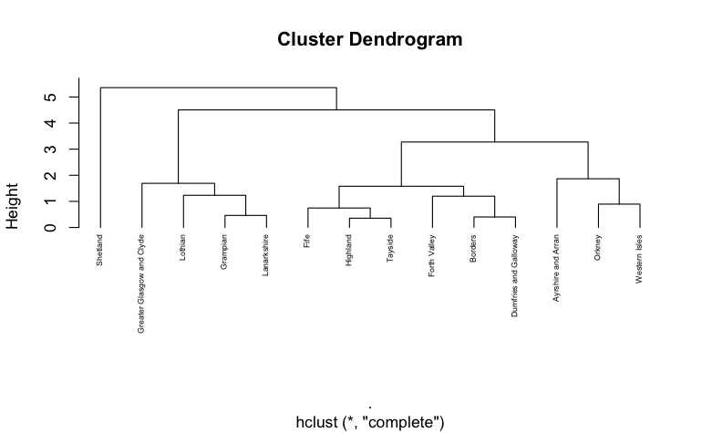

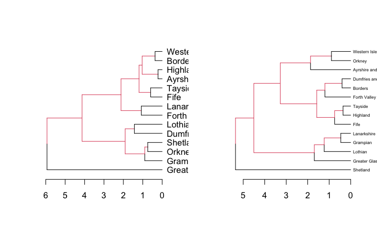

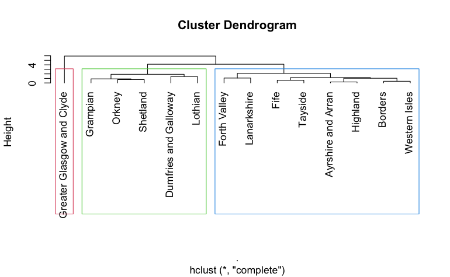

These plots show the results of a clustering analysis clustering health boards based on incidence and mortality rates given the most recent year. Summing up all incidences and deaths for all age groups and genders. The grouping into 3 distinct clusters is arbitrarily chosen, minimum requirement was to reduce the number of groups consisting of 2 healthboards.

Looking at the clustering based on incidence rates we identify two major groups, leaving ‘Greater Glasgow and Clyde’ as a unique healthboard. I recommend for the remaining health boards to collaborate and set up improvements plans together as their incidence rates show highly similar patterns.